# Упражнение 7

Никишов Дмитрий

12 05 2021

Нелинейные модели Необходимо построить две модели:

- зависимости непрерывного отклика от одного непрерывного предиктора;
- зависимости вероятности (логит) от одного непрерывного предиктора.

Для каждой модели:

1 Указать смысл переменных модели, метод оценки и настроечный параметр (степень полинома, гиперпараметр λ, ширина окна s, число узлов – в зависимости от метода).

2 Подогнать модель на всех наблюдениях, меняя значение настроечного параметра.

3 Обосновать оптимальное значение настроечного параметра подходящим методом (кросс-валидация, ANOVA).

4 Сделать прогноз на обучающую выборку по лучшей модели: модельные значения и ошибки прогноза.

5 Построить график с фактическими наблюдениями, модельной кривой и 95% доверительными интервалами прогноза.

В таблице ниже указаны набор данных, столбцы с переменными для модели и метод подгонки.

Как сдавать: прислать на почту преподавателя ссылки:

- на html-отчёт с видимыми блоками кода (блоки кода с параметром echo = T), размещённый на rpubs.com.
- на код, генерирующий отчёт, в репозитории на github.com. В текст отчёта включить постановку задачи и ответы на вопросы задания.

# Вариант - 21 (3)

Модели: локальная регрессия.

Данные: *`Boston {MASS}’*.

Работаем с набором данных по стоимости жилья в пригороде Бостона. Присоединяем его к пространству имён функцией attach(), и дальше обращаемся напрямую к столбцам таблицы.

```r
attach(Boston)

#?Boston
```

Работаем со столбцами:

- *crim* – уровень преступности на душу населения по городам;
- *nox* – концентрация оксидов азота (частей на 10 миллионов).

##Локальная регрессия

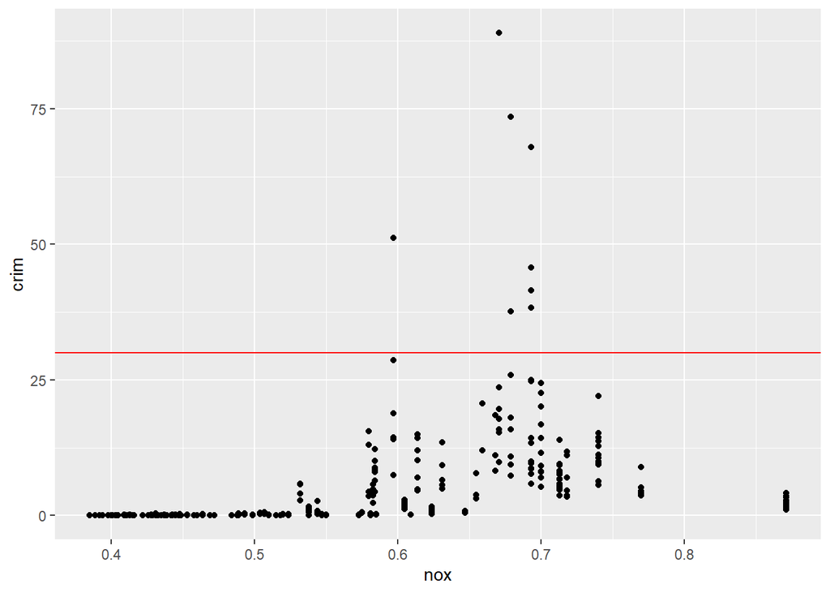

```r
gp <- ggplot(data = Boston, aes(x = nox, y = crim))
gp <- gp + geom_point() + geom_abline(slope = 0, intercept = 30, col = 'red')
gp
```

# Зависимость уровня преступности от концентрации азота (модель 1)

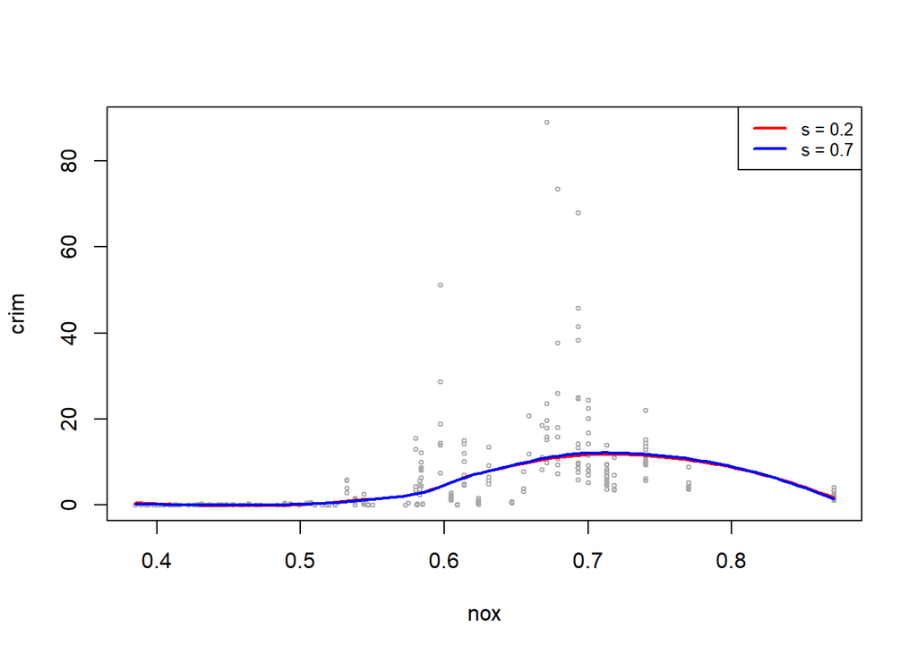

```r
# границы изменения переменной nox
noxlims <- range(nox)

# значения nox, для которых делаем прогноз (от min до max с шагом 1)
nox.grid <- seq(from = noxlims[1], to = noxlims[2], length = 100)

# график
plot(nox, crim, xlim = noxlims, cex = 0.5, col = 'darkgrey')


# подгоняем модель c окном 0.2
fit1 <- loess(crim ~ nox, cv = 0.2, data = Boston)

# подгоняем модель c окном 0.7
fit2 <- loess(crim ~ nox, span = 0.7, data = Boston)

# рисум модели
lines(nox.grid, predict(fit1, data.frame(nox = nox.grid)),
      col = 'red', lwd = 2)
lines(nox.grid, predict(fit2, data.frame(nox = nox.grid)),
      col = 'blue', lwd = 2)

# легенда
legend('topright',
       c('s = 0.2', 's = 0.7'),
       col = c('red', 'blue'), lty = 1, lwd = 2, cex = 0.8)
```

#Определение оптимального настроечного параметра (модель 1)

Подбор настроечного параметра (ширина окна s) осуществим с помощью кросс-валидации. Для того, чтобы параметр был оптимальным, необходимо минимизировать ошибку СV. Чем меньше окажется ширина окна, тем более локальной и извилистой будет модедь; в то же время очень большое значение параметра s приведёт к глобальной модели, построенной по всей обучающей выборке.

```r
# подгоняем модель с подбором ширины окна с помощью перекрёстной проверки
fit <- loess(crim ~ nox, cv = T, data = Boston)
# параметр span
fit$pars
```

```
## $span
## [1] 0.75
##
## $degree
## [1] 2
##
## $normalize
## [1] TRUE
##
## $parametric
## [1] FALSE
##
## $drop.square
## [1] FALSE
##
## $surface
## [1] "interpolate"
##
## $cell
## [1] 0.2
##
## $family
## [1] "gaussian"
##
## $trace.hat
## [1] "exact"
##
## $iterations
## [1] 1
```

```r
# лучшая модель (с окном 0.75)

best.fit1 <- loess(crim ~ nox, span = 0.75, data = Boston)
```

#Прогноз на обучающую выборку по лучшей модели (модель 1)

```r
# прогноз по лучшей модели
preds <- predict(best.fit1, data.frame(nox = nox.grid), se = T)

# границы доверительного интервала для площади нерозничных торговых площадей
se.bands <- cbind(lower.bound = preds$fit - 2*preds$se.fit,
                  upper.bound = preds$fit + 2*preds$se.fit)

# смотрим результат
round(head(se.bands), 2)
```

```
##   lower.bound upper.bound
## 1       -2.33        3.37
## 2       -2.12        2.99
## 3       -1.93        2.64
## 4       -1.75        2.32
## 5       -1.59        2.03
## 6       -1.46        1.78
```

```r
# стандартные ошибки
round(preds$se.fit, 2)
```

```
##    1    2    3    4    5    6    7    8    9   10   11   12   13   14   15   16
## 1.43 1.28 1.14 1.02 0.91 0.81 0.72 0.65 0.60 0.56 0.54 0.52 0.52 0.52 0.53 0.54
##   17   18   19   20   21   22   23   24   25   26   27   28   29   30   31   32
## 0.54 0.55 0.56 0.57 0.58 0.59 0.59 0.59 0.58 0.58 0.58 0.59 0.59 0.60 0.60 0.60
##   33   34   35   36   37   38   39   40   41   42   43   44   45   46   47   48
## 0.59 0.58 0.57 0.57 0.58 0.59 0.61 0.63 0.64 0.64 0.64 0.63 0.63 0.63 0.63 0.64
##   49   50   51   52   53   54   55   56   57   58   59   60   61   62   63   64
## 0.64 0.64 0.63 0.63 0.62 0.61 0.60 0.60 0.59 0.59 0.59 0.60 0.60 0.61 0.62 0.62
##   65   66   67   68   69   70   71   72   73   74   75   76   77   78   79   80
## 0.63 0.63 0.64 0.65 0.65 0.66 0.66 0.67 0.68 0.69 0.70 0.71 0.72 0.74 0.76 0.77
##   81   82   83   84   85   86   87   88   89   90   91   92   93   94   95   96
## 0.79 0.82 0.84 0.87 0.90 0.94 0.97 1.01 1.05 1.10 1.15 1.20 1.25 1.31 1.37 1.43
##   97   98   99  100
## 1.50 1.56 1.63 1.71
```

#График с фактическими наблюдениями, модельной кривой и 95% доверительными интервалами прогноза (модель 1)

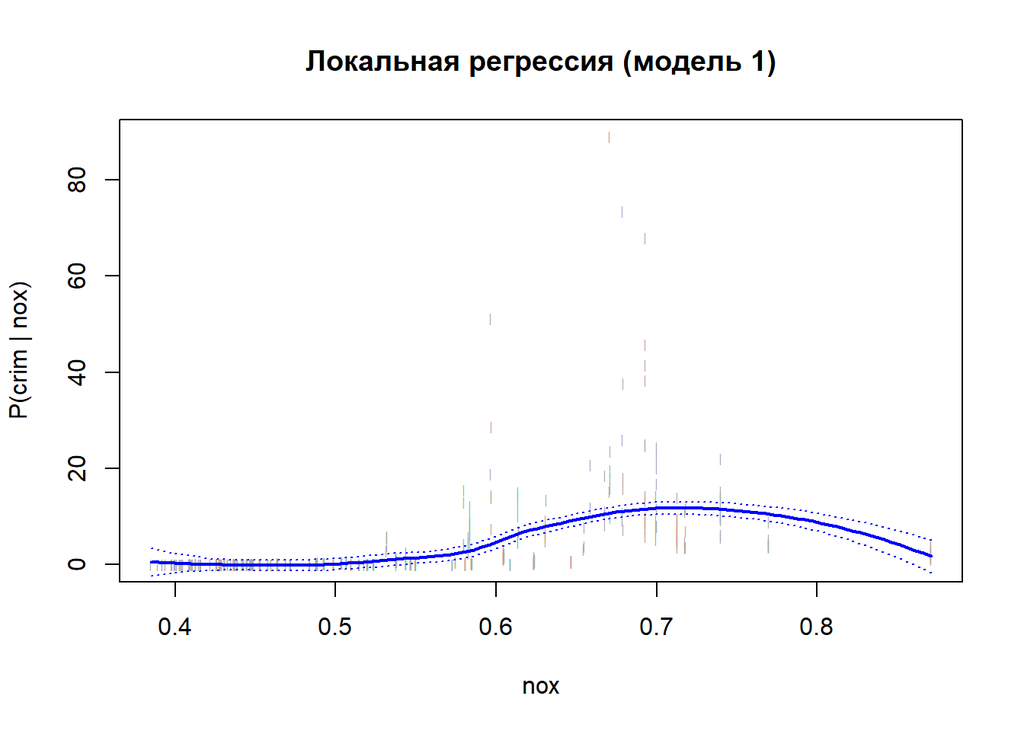

```r
plot(nox, crim, xlim = noxlims, type = 'n', ylab = 'P(crim | nox)')

# фактические наблюдения показываем засечками
points(jitter(nox), crim, cex = 0.5, pch = '|', col = 'darkgrey')

pfit <- preds$fit

# модель
lines(nox.grid, pfit, lwd = 2, col = 'blue')

# доверительные интервалы
matlines(nox.grid, se.bands, lwd = 1, col = 'blue', lty = 3)

# заголовок
title('Локальная регрессия (модель 1)')
```

#Зависимость вероятности уровня премтупности > 30 от концентрации азота (модель 2)

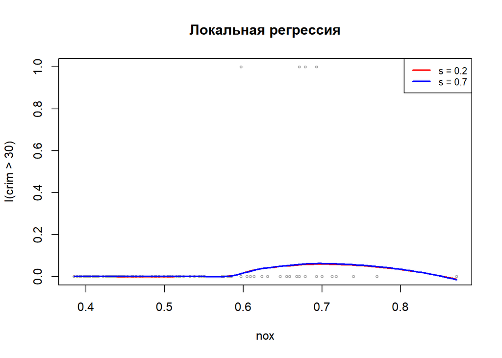

```r
# график
plot(nox, I(crim>30), xlim = noxlims, cex = 0.5, col = 'darkgrey')

title('Локальная регрессия')

# подгоняем модель c окном 0.2
fit3 <- loess(I(crim>30) ~ nox, cv = 0.2, data = Boston)

# подгоняем модель c окном 0.7
fit4 <- loess(I(crim>30) ~ nox, span = 0.7, data = Boston)

# рисум модели
lines(nox.grid, predict(fit3, data.frame(nox = nox.grid)),
      col = 'red', lwd = 2)
lines(nox.grid, predict(fit4, data.frame(nox = nox.grid)),
      col = 'blue', lwd = 2)

# легенда
legend('topright',
       c('s = 0.2', 's = 0.7'),
       col = c('red', 'blue'), lty = 1, lwd = 2, cex = 0.8)
```

#Определение оптимального настроечного параметра (модель 2)

```r
# подгоняем модель с подбором ширины окна с помощью перекрёстной проверки
fit <- loess(I(crim>30) ~ nox, cv = T, data = Boston)
# параметр span
fit$pars
```

```
## $span
## [1] 0.75
##
## $degree
## [1] 2
##
## $normalize
## [1] TRUE
##
## $parametric
## [1] FALSE
##
## $drop.square
## [1] FALSE
##
## $surface
## [1] "interpolate"
##
## $cell
## [1] 0.2
##
## $family
## [1] "gaussian"
##
## $trace.hat
## [1] "exact"
##
## $iterations
## [1] 1
```

```r
best.fit2 <- loess(I(crim>30) ~ nox, span = 0.75, data = Boston)
```

#Прогноз на обучающую выборку по лучшей модели (модель 2)

```r
# прогнозы
preds <- predict(best.fit2, data.frame(nox = nox.grid), se = T)

# пересчитываем доверительные интервалы и прогнозы в исходные ЕИ
pfit <- exp(preds$fit) / (1 + exp(preds$fit))
se.bands.loess <- cbind(lower.bound = preds$fit - 2*preds$se.fit,
                        upper.bound = preds$fit + 2*preds$se.fit)
se.bands <- exp(se.bands.loess)/(1 + exp(se.bands.loess))


round(head(se.bands), 3)
```

```
##   lower.bound upper.bound
## 1       0.488       0.513
## 2       0.489       0.511
## 3       0.490       0.510
## 4       0.491       0.509
## 5       0.492       0.508
## 6       0.493       0.507
```

```r
round(preds$se.fit, 2)
```

```
##    1    2    3    4    5    6    7    8    9   10   11   12   13   14   15   16
## 0.02 0.02 0.02 0.02 0.02 0.01 0.01 0.01 0.01 0.01 0.01 0.01 0.01 0.01 0.01 0.01
##   17   18   19   20   21   22   23   24   25   26   27   28   29   30   31   32
## 0.01 0.01 0.01 0.01 0.01 0.01 0.01 0.01 0.01 0.01 0.01 0.01 0.01 0.01 0.01 0.01
##   33   34   35   36   37   38   39   40   41   42   43   44   45   46   47   48
## 0.01 0.01 0.01 0.01 0.01 0.01 0.01 0.01 0.01 0.01 0.01 0.01 0.01 0.01 0.01 0.01
##   49   50   51   52   53   54   55   56   57   58   59   60   61   62   63   64
## 0.01 0.01 0.01 0.01 0.01 0.01 0.01 0.01 0.01 0.01 0.01 0.01 0.01 0.01 0.01 0.01
##   65   66   67   68   69   70   71   72   73   74   75   76   77   78   79   80
## 0.01 0.01 0.01 0.01 0.01 0.01 0.01 0.01 0.01 0.01 0.01 0.01 0.01 0.01 0.01 0.01
##   81   82   83   84   85   86   87   88   89   90   91   92   93   94   95   96
## 0.01 0.01 0.01 0.01 0.02 0.02 0.02 0.02 0.02 0.02 0.02 0.02 0.02 0.02 0.02 0.02
##   97   98   99  100
## 0.03 0.03 0.03 0.03
```

#График с фактическими наблюдениями, модельной кривой и 95% доверительными интервалами прогноза (модель 2)

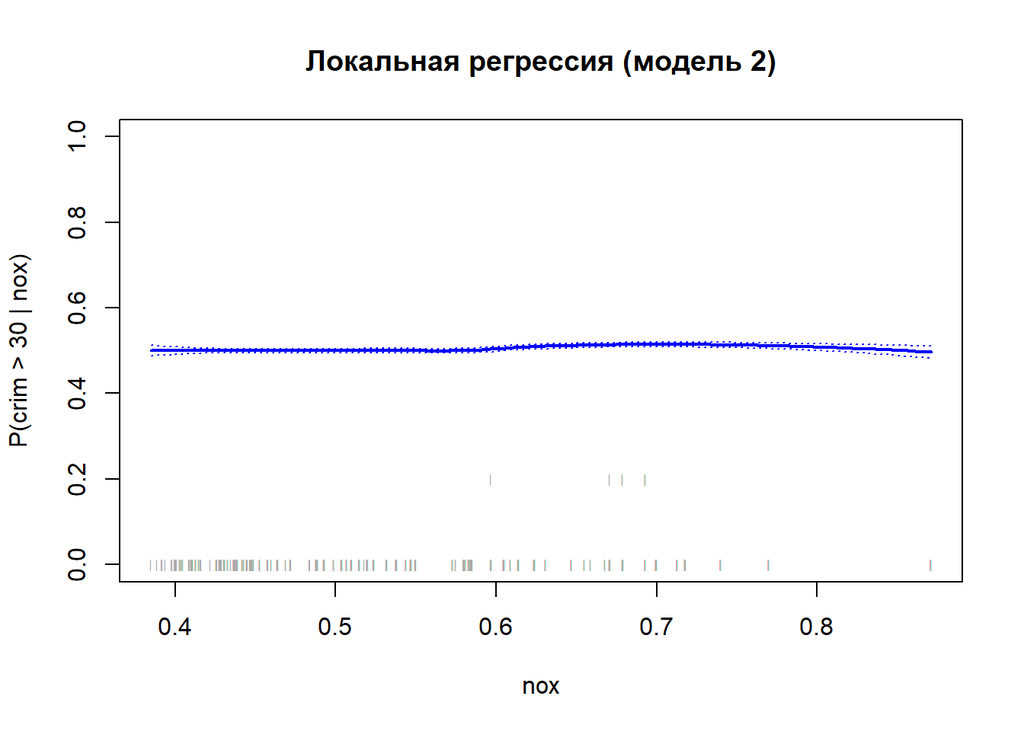

```r
# сетка для графика (изображаем вероятности, поэтому интервал изменения y мал)
plot(nox, I(crim > 30), xlim = noxlims, type = 'n', ylim = c(0, 1),
     ylab = 'P(crim > 30 | nox)')

# фактические наблюдения показываем засечками
points(jitter(nox), I((crim > 30)/5 ), cex = 0.5, pch = '|', col = 'darkgrey')

# модель
lines(nox.grid, pfit, lwd = 2, col = 'blue')

# доверительные интервалы
matlines(nox.grid, se.bands, lwd = 1, col = 'blue', lty = 3)

# заголовок
title('Локальная регрессия (модель 2)')
```